# ie360 Project

Mert Kaan - Hakan Ekiz

1/28/2021

# Inroduction

# Data

In order to use data more efficiently, we did some manipulations such as converting double hour values into factors, converting consumption into numeric, numbering every observation and sorting the data an increasing order with respect to its date.

```
##          Date Hour Consumption    T_1  T_2  T_3    T_4    T_5    T_6  T_7 index
## 1: 2017-01-01    0    25409.31 -15.88 4.18 0.89 -18.96 -14.77 -10.68 2.16     1
## 2: 2017-01-01    1    24166.14 -15.88 4.18 0.89 -18.96 -14.77 -10.68 2.16     2
## 3: 2017-01-01    2    22652.02 -15.88 4.18 0.89 -18.96 -14.77 -10.68 2.16     3
## 4: 2017-01-01    3    21578.05 -15.88 4.18 0.89 -18.96 -14.77 -10.68 2.16     4
## 5: 2017-01-01    4    21018.20 -15.88 4.18 0.89 -18.96 -14.77 -10.68 2.16     5
## 6: 2017-01-01    5    20953.17 -15.88 4.18 0.89 -18.96 -14.77 -10.68 2.16     6
##    Average_T_1 Average_T_2 Average_T_3 Average_T_4 Average_T_5 Average_T_6
## 1:   -10.12542    6.165833    2.808333   -13.21625   -10.74208   -8.598333
## 2:   -10.12542    6.165833    2.808333   -13.21625   -10.74208   -8.598333
## 3:   -10.12542    6.165833    2.808333   -13.21625   -10.74208   -8.598333
## 4:   -10.12542    6.165833    2.808333   -13.21625   -10.74208   -8.598333
## 5:   -10.12542    6.165833    2.808333   -13.21625   -10.74208   -8.598333
## 6:   -10.12542    6.165833    2.808333   -13.21625   -10.74208   -8.598333
##    Average_T_7 Month   Day
## 1:     2.68625     1 Pazar
## 2:     2.68625     1 Pazar
## 3:     2.68625     1 Pazar
## 4:     2.68625     1 Pazar
## 5:     2.68625     1 Pazar
## 6:     2.68625     1 Pazar
```

# Forecasting Models

### Model1

In our Model1 we use daily average temperature values of 7 different locations and Hour information. After creating histogram of residuals of model 1 we can see that this model can not be sufficient since residuals of it does not behave symmetric. This model does not include seasonality related factors such as effect of month or index. We should add them to improve our model since we observe evident proof of seasonality in our residuals.

```r
model1 = lm(data$Consumption~ data$Average_T_1 +  data$Average_T_2 + data$Average_T_3 +data$Average_T_4 +data$Average_T_5 +data$Average_T_6 +data$Average_T_7 + data$Hour  )
summary(model1)
```

```
##
## Call:
## lm(formula = data$Consumption ~ data$Average_T_1 + data$Average_T_2 +
##     data$Average_T_3 + data$Average_T_4 + data$Average_T_5 +
##     data$Average_T_6 + data$Average_T_7 + data$Hour)
##
## Residuals:
##    Min     1Q Median     3Q    Max
## -34783  -1922    194   2434  12496
##
## Coefficients:
##                  Estimate Std. Error t value Pr(>|t|)
## (Intercept)      34060.94     190.34 178.947   <2e-16 ***
## data$Average_T_1   543.86      15.83  34.362   <2e-16 ***
## data$Average_T_2  -499.80      12.25 -40.800   <2e-16 ***
## data$Average_T_3  -254.36      15.62 -16.283   <2e-16 ***
## data$Average_T_4  -239.58      17.66 -13.568   <2e-16 ***
## data$Average_T_5  -495.59      16.10 -30.773   <2e-16 ***
## data$Average_T_6   490.16      20.15  24.325   <2e-16 ***
## data$Average_T_7   532.50      12.61  42.237   <2e-16 ***
## data$Hour1       -1546.80     138.53 -11.165   <2e-16 ***
## data$Hour2       -2617.46     138.53 -18.894   <2e-16 ***
## data$Hour3       -3319.46     138.53 -23.961   <2e-16 ***
## data$Hour4       -3632.55     138.53 -26.221   <2e-16 ***
## data$Hour5       -3822.53     138.53 -27.593   <2e-16 ***
## data$Hour6       -3010.42     138.53 -21.730   <2e-16 ***
## data$Hour7       -1944.74     138.53 -14.038   <2e-16 ***
## data$Hour8        1297.71     138.53   9.367   <2e-16 ***
## data$Hour9        3522.41     138.53  25.426   <2e-16 ***
## data$Hour10       4386.69     138.53  31.665   <2e-16 ***
## data$Hour11       5023.52     138.53  36.262   <2e-16 ***
## data$Hour12       3949.48     138.53  28.509   <2e-16 ***
## data$Hour13       4305.46     138.53  31.079   <2e-16 ***
## data$Hour14       4945.50     138.53  35.699   <2e-16 ***
## data$Hour15       4770.45     138.53  34.435   <2e-16 ***
## data$Hour16       4834.41     138.53  34.897   <2e-16 ***
## data$Hour17       4809.28     138.53  34.715   <2e-16 ***
## data$Hour18       4750.54     138.53  34.291   <2e-16 ***
## data$Hour19       4821.44     138.53  34.803   <2e-16 ***
## data$Hour20       4696.50     138.53  33.901   <2e-16 ***
## data$Hour21       4063.53     138.53  29.332   <2e-16 ***
## data$Hour22       3290.90     138.53  23.755   <2e-16 ***
## data$Hour23       1929.19     138.53  13.926   <2e-16 ***
## ---
## Signif. codes:  0 '***' 0.001 '**' 0.01 '*' 0.05 '.' 0.1 ' ' 1
##
## Residual standard error: 3804 on 36161 degrees of freedom
## Multiple R-squared:  0.4643, Adjusted R-squared:  0.4638
## F-statistic:  1045 on 30 and 36161 DF,  p-value: < 2.2e-16
```

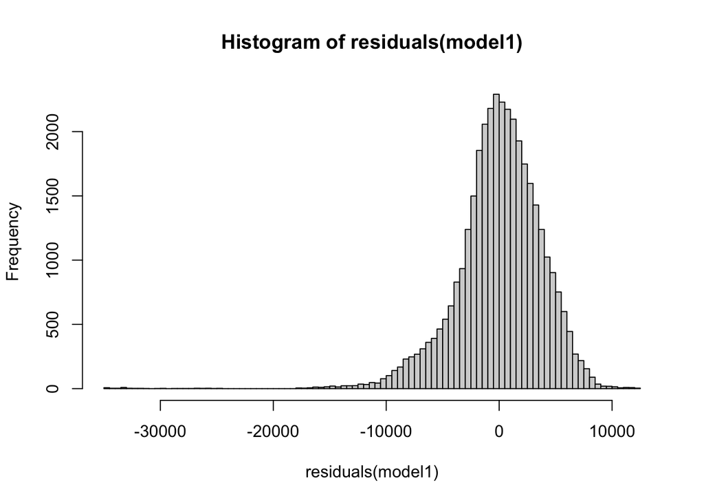

```r
data[, residuals1 := residuals(model1)]
data[, prediction1 := fitted(model1)]


hist(residuals(model1) , breaks = 100)
```

### Model2

In our Model2 we use hourly temperature values of 7 different locations, month,day, hour information and index.It is better than model1 in terms of deviation of our answers, but still it is not sufficient since our residuals do not follow normal distribution. We are not using the effects of previous consumption values and this deficiency may be causing high autocorrelations between the residuals of our models. By using some of the previous values, our model can predict the next values more accurately. To determine which dates’ values will be used we should look the pacf of model2 residuals.

```r
model2 = lm(data$Consumption~ data$T_1 + data$T_2 + data$T_3 + data$T_4 + data$T_5 + data$T_6 + data$T_7  + data$index + data$Month + data$Day + data$Hour )
summary(model2)
```

```
##
## Call:
## lm(formula = data$Consumption ~ data$T_1 + data$T_2 + data$T_3 +
##     data$T_4 + data$T_5 + data$T_6 + data$T_7 + data$index +
##     data$Month + data$Day + data$Hour)
##
## Residuals:
##    Min     1Q Median     3Q    Max
## -36884  -1266    220   1611  10151
##
## Coefficients:
##                     Estimate Std. Error t value Pr(>|t|)
## (Intercept)        3.184e+04  1.457e+02 218.510  < 2e-16 ***
## data$T_1           7.898e+00  9.340e+00   0.846 0.397778
## data$T_2          -1.739e+02  8.371e+00 -20.771  < 2e-16 ***
## data$T_3           1.818e+01  9.449e+00   1.924 0.054306 .
## data$T_4           8.882e+01  1.011e+01   8.782  < 2e-16 ***
## data$T_5          -1.179e+02  1.072e+01 -10.995  < 2e-16 ***
## data$T_6           7.093e+01  1.179e+01   6.016 1.80e-09 ***
## data$T_7           1.412e+02  9.258e+00  15.252  < 2e-16 ***
## data$index         6.441e-02  1.524e-03  42.249  < 2e-16 ***
## data$Month2       -7.641e+02  7.135e+01 -10.710  < 2e-16 ***
## data$Month3       -2.312e+03  7.749e+01 -29.838  < 2e-16 ***
## data$Month4       -4.148e+03  8.649e+01 -47.956  < 2e-16 ***
## data$Month5       -4.434e+03  1.081e+02 -40.998  < 2e-16 ***
## data$Month6       -3.372e+03  1.315e+02 -25.647  < 2e-16 ***
## data$Month7        1.926e+03  1.455e+02  13.236  < 2e-16 ***
## data$Month8        1.059e+03  1.458e+02   7.264 3.84e-13 ***
## data$Month9       -3.676e+02  1.334e+02  -2.756 0.005850 **
## data$Month10      -3.426e+03  1.114e+02 -30.746  < 2e-16 ***
## data$Month11      -1.966e+03  8.667e+01 -22.678  < 2e-16 ***
## data$Month12      -2.101e+02  7.371e+01  -2.850 0.004375 **
## data$DayCumartesi -1.641e+03  5.607e+01 -29.277  < 2e-16 ***
## data$DayÇarşamba   1.743e+02  5.609e+01   3.107 0.001892 **
## data$DayPazar     -4.797e+03  5.602e+01 -85.634  < 2e-16 ***
## data$DayPazartesi -1.069e+03  5.610e+01 -19.060  < 2e-16 ***
## data$DayPerşembe   2.986e+02  5.606e+01   5.327 1.00e-07 ***
## data$DaySalı      -2.143e+02  5.609e+01  -3.821 0.000133 ***
## data$Hour1        -1.536e+03  1.037e+02 -14.814  < 2e-16 ***
## data$Hour2        -2.593e+03  1.038e+02 -24.992  < 2e-16 ***
```

[output cut: 12 more lines]

```
## data$Hour15        5.499e+03  1.149e+02  47.838  < 2e-16 ***
## data$Hour16        5.458e+03  1.133e+02  48.167  < 2e-16 ***
## data$Hour17        5.299e+03  1.113e+02  47.598  < 2e-16 ***
## data$Hour18        5.071e+03  1.089e+02  46.572  < 2e-16 ***
## data$Hour19        5.000e+03  1.065e+02  46.952  < 2e-16 ***
## data$Hour20        4.781e+03  1.050e+02  45.550  < 2e-16 ***
## data$Hour21        4.072e+03  1.041e+02  39.120  < 2e-16 ***
## data$Hour22        3.291e+03  1.038e+02  31.698  < 2e-16 ***
## data$Hour23        1.927e+03  1.037e+02  18.581  < 2e-16 ***
## ---
## Signif. codes:  0 '***' 0.001 '**' 0.01 '*' 0.05 '.' 0.1 ' ' 1
##
## Residual standard error: 2846 on 36143 degrees of freedom
## Multiple R-squared:  0.7002, Adjusted R-squared:  0.6998
## F-statistic:  1759 on 48 and 36143 DF,  p-value: < 2.2e-16
```

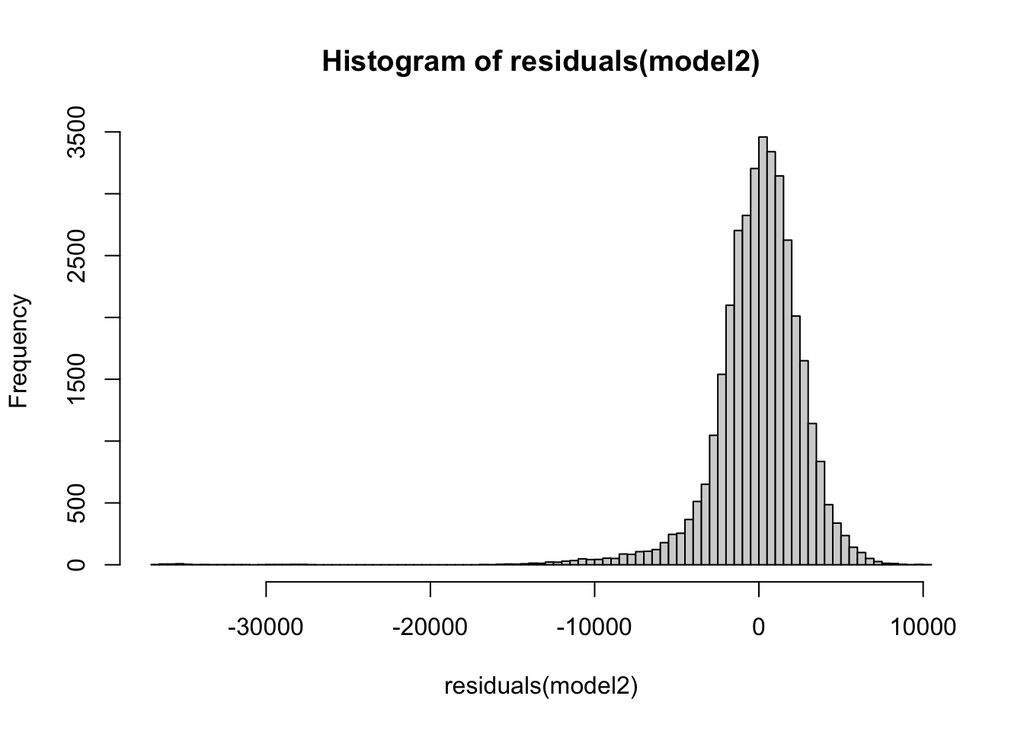

```r
data[, residuals2 := residuals(model2)]
data[ , prediction2 := fitted(model2)]

hist(residuals(model2) , breaks= 100)
```

## Fixing the Outliers

Since we knew the reason behind being an outlier observation in the case, being observed during a special day, and we knew that in the suration of this project we will not face such a special day, what we did was discarding this special days’ observations by replacing their consumption values by their predictions we have made from out last model.

```r
#ggplot(data) + geom_line(aes( x = Date , y = residuals2) , color = "dark blue")
#ggplot(data) + geom_line(aes( x = Date , y = Consumption) , color = "dark blue")
data[ data$residuals2 < -7000]$Consumption = data[ data$residuals2 < -7000]$prediction2
data[ data$residuals2 > 8000]$Consumption = data[ data$residuals2 > 8000]$prediction2
#ggplot(data) + geom_line(aes( x = Date , y = Consumption) , color = "dark blue" )
```

### Model3

In our Model3 we use temperature values of 7 different locations, month,day, hour information, index and prevday2, indicates that not the 48 lags data.In the model 3 we can examine the effect of prevday2 in addition to model2 as an evident regressor. It is better than model2 but still open to improvements.

```r
data[,prevday2:=shift(x=data$Consumption,n=48L,fill=mean(data$Consumption))]
data[,prevweek:=shift(x=data$Consumption,n=168L,fill=mean(data$Consumption))]
model3 = lm(data$Consumption~data$Day + data$T_1 + data$T_2 + data$T_3 + data$T_4 + data$T_5 + data$T_6 + data$T_7   + data$index + data$Month + data$Hour  + data$prevday2  )
summary(model3)
```

```
##
## Call:
## lm(formula = data$Consumption ~ data$Day + data$T_1 + data$T_2 +
##     data$T_3 + data$T_4 + data$T_5 + data$T_6 + data$T_7 + data$index +
##     data$Month + data$Hour + data$prevday2)
##
## Residuals:
##     Min      1Q  Median      3Q     Max
## -8921.7 -1038.0    79.2  1141.6  8948.4
##
## Coefficients:
##                     Estimate Std. Error  t value Pr(>|t|)
## (Intercept)        1.641e+04  1.720e+02   95.446  < 2e-16 ***
## data$DayCumartesi -1.702e+03  3.692e+01  -46.113  < 2e-16 ***
## data$DayÇarşamba   6.299e+02  3.726e+01   16.909  < 2e-16 ***
## data$DayPazar     -4.814e+03  3.689e+01 -130.491  < 2e-16 ***
## data$DayPazartesi -1.255e+02  3.780e+01   -3.322 0.000896 ***
## data$DayPerşembe   3.079e+02  3.692e+01    8.342  < 2e-16 ***
## data$DaySalı       2.378e+03  4.335e+01   54.855  < 2e-16 ***
## data$T_1           3.323e+01  6.152e+00    5.402 6.63e-08 ***
## data$T_2          -7.724e+01  5.530e+00  -13.967  < 2e-16 ***
## data$T_3          -1.862e+01  6.222e+00   -2.993 0.002768 **
## data$T_4           4.460e+01  6.665e+00    6.691 2.24e-11 ***
## data$T_5          -5.371e+01  7.072e+00   -7.596 3.13e-14 ***
## data$T_6           2.665e+01  7.763e+00    3.433 0.000597 ***
## data$T_7           5.363e+01  6.127e+00    8.752  < 2e-16 ***
## data$index         3.831e-02  1.063e-03   36.036  < 2e-16 ***
## data$Month2       -2.110e+02  4.698e+01   -4.492 7.09e-06 ***
## data$Month3       -1.291e+03  5.171e+01  -24.976  < 2e-16 ***
## data$Month4       -2.075e+03  5.917e+01  -35.063  < 2e-16 ***
## data$Month5       -2.065e+03  7.324e+01  -28.201  < 2e-16 ***
## data$Month6       -1.332e+03  8.752e+01  -15.219  < 2e-16 ***
## data$Month7        1.163e+03  9.641e+01   12.060  < 2e-16 ***
## data$Month8        8.427e+02  9.657e+01    8.727  < 2e-16 ***
## data$Month9       -2.179e+02  8.781e+01   -2.482 0.013070 *
## data$Month10      -1.886e+03  7.478e+01  -25.227  < 2e-16 ***
## data$Month11      -9.773e+02  5.794e+01  -16.869  < 2e-16 ***
## data$Month12      -2.390e+02  4.854e+01   -4.923 8.54e-07 ***
## data$Hour1        -7.925e+02  6.864e+01  -11.546  < 2e-16 ***
## data$Hour2        -1.342e+03  6.938e+01  -19.349  < 2e-16 ***
```

[output cut: 13 more lines]

```
## data$Hour16        2.886e+03  7.891e+01   36.567  < 2e-16 ***
## data$Hour17        2.809e+03  7.747e+01   36.255  < 2e-16 ***
## data$Hour18        2.690e+03  7.562e+01   35.576  < 2e-16 ***
## data$Hour19        2.632e+03  7.398e+01   35.572  < 2e-16 ***
## data$Hour20        2.496e+03  7.263e+01   34.366  < 2e-16 ***
## data$Hour21        2.119e+03  7.113e+01   29.785  < 2e-16 ***
## data$Hour22        1.711e+03  7.007e+01   24.422  < 2e-16 ***
## data$Hour23        1.002e+03  6.887e+01   14.544  < 2e-16 ***
## data$prevday2      4.900e-01  4.568e-03  107.277  < 2e-16 ***
## ---
## Signif. codes:  0 '***' 0.001 '**' 0.01 '*' 0.05 '.' 0.1 ' ' 1
##
## Residual standard error: 1874 on 36142 degrees of freedom
## Multiple R-squared:  0.8559, Adjusted R-squared:  0.8557
## F-statistic:  4382 on 49 and 36142 DF,  p-value: < 2.2e-16
```

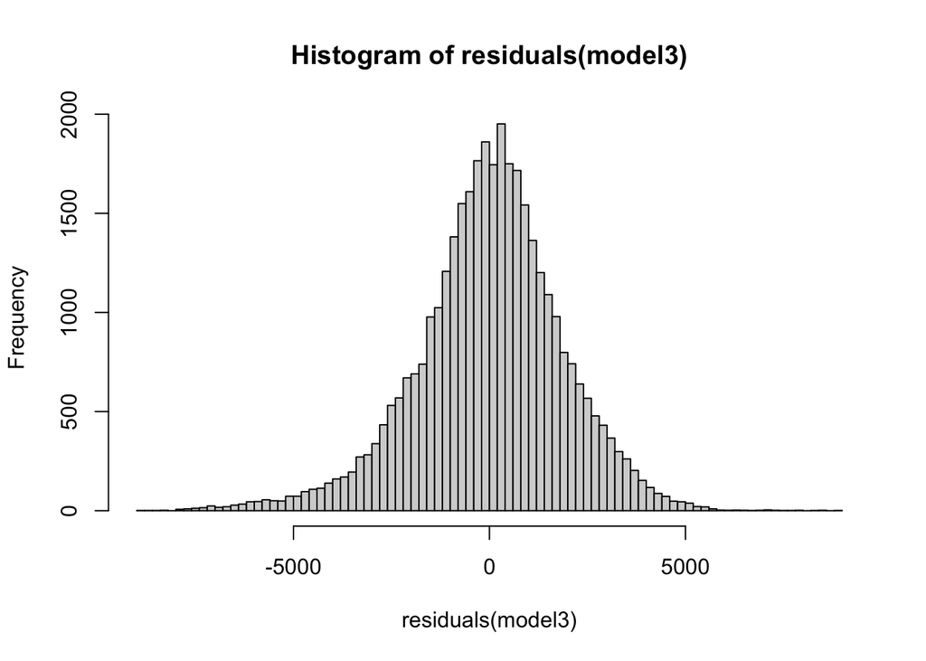

```r
data[, residuals3 := residuals(model3)]
data[, prediction3 := fitted(model3)]

hist(residuals(model3),  breaks = 100)
```

### Model4

In our Model4 we use daily mean temperature values of 7 different locations, month,day, hour information, index, prevday2 and prevweek.In the model 4 we can examine the effect of prevweek in addition to model2. It is better than model2 but still it is not sufficient. We should fix the extreme values to improve the model accuracy.

```r
model4 = lm(data$Consumption~data$Day + data$Average_T_1 +  data$Average_T_2 + data$Average_T_3 +data$Average_T_4 +data$Average_T_5 +data$Average_T_6 +data$Average_T_7 + data$index + data$Month + data$Hour + data$prevweek +data$prevday2 )
summary(model4)
```

```
##
## Call:
## lm(formula = data$Consumption ~ data$Day + data$Average_T_1 +
##     data$Average_T_2 + data$Average_T_3 + data$Average_T_4 +
##     data$Average_T_5 + data$Average_T_6 + data$Average_T_7 +
##     data$index + data$Month + data$Hour + data$prevweek + data$prevday2)
##
## Residuals:
##     Min      1Q  Median      3Q     Max
## -9854.5  -766.9    64.6   848.2 10982.0
##
## Coefficients:
##                     Estimate Std. Error t value Pr(>|t|)
## (Intercept)        7.217e+03  1.722e+02  41.907  < 2e-16 ***
## data$DayCumartesi -8.364e+02  3.153e+01 -26.526  < 2e-16 ***
## data$DayÇarşamba   3.534e+02  3.114e+01  11.348  < 2e-16 ***
## data$DayPazar     -2.366e+03  3.636e+01 -65.053  < 2e-16 ***
## data$DayPazartesi  1.729e+01  3.154e+01   0.548  0.58348
## data$DayPerşembe   1.528e+02  3.081e+01   4.959 7.10e-07 ***
## data$DaySalı       1.382e+03  3.700e+01  37.348  < 2e-16 ***
## data$Average_T_1   7.660e+01  7.133e+00  10.739  < 2e-16 ***
## data$Average_T_2  -8.111e+01  6.173e+00 -13.139  < 2e-16 ***
## data$Average_T_3   2.214e+01  7.627e+00   2.902  0.00370 **
## data$Average_T_4  -1.618e+00  7.457e+00  -0.217  0.82818
## data$Average_T_5  -9.387e+01  7.888e+00 -11.900  < 2e-16 ***
## data$Average_T_6   8.681e+01  8.919e+00   9.733  < 2e-16 ***
## data$Average_T_7   3.671e+00  6.659e+00   0.551  0.58143
## data$index         1.611e-02  9.354e-04  17.225  < 2e-16 ***
## data$Month2       -2.713e+02  3.969e+01  -6.836 8.25e-12 ***
## data$Month3       -8.763e+02  4.446e+01 -19.710  < 2e-16 ***
## data$Month4       -1.197e+03  5.236e+01 -22.867  < 2e-16 ***
## data$Month5       -1.026e+03  6.742e+01 -15.213  < 2e-16 ***
## data$Month6       -4.749e+02  8.175e+01  -5.810 6.31e-09 ***
## data$Month7        5.337e+02  8.898e+01   5.998 2.02e-09 ***
## data$Month8       -2.600e+02  8.920e+01  -2.915  0.00356 **
## data$Month9       -7.414e+02  8.100e+01  -9.154  < 2e-16 ***
## data$Month10      -1.188e+03  6.962e+01 -17.061  < 2e-16 ***
## data$Month11      -1.617e+01  5.215e+01  -0.310  0.75651
## data$Month12      -1.176e+02  4.117e+01  -2.857  0.00428 **
## data$Hour1        -3.251e+02  5.733e+01  -5.671 1.43e-08 ***
```

[output cut: 15 more lines]

```
## data$Hour17        1.040e+03  6.115e+01  17.013  < 2e-16 ***
## data$Hour18        1.021e+03  6.099e+01  16.743  < 2e-16 ***
## data$Hour19        1.026e+03  6.102e+01  16.808  < 2e-16 ***
## data$Hour20        9.887e+02  6.075e+01  16.274  < 2e-16 ***
## data$Hour21        8.531e+02  5.979e+01  14.268  < 2e-16 ***
## data$Hour22        6.922e+02  5.882e+01  11.768  < 2e-16 ***
## data$Hour23        4.061e+02  5.757e+01   7.054 1.77e-12 ***
## data$prevweek      5.086e-01  4.038e-03 125.951  < 2e-16 ***
## data$prevday2      2.850e-01  4.141e-03  68.827  < 2e-16 ***
## ---
## Signif. codes:  0 '***' 0.001 '**' 0.01 '*' 0.05 '.' 0.1 ' ' 1
##
## Residual standard error: 1562 on 36141 degrees of freedom
## Multiple R-squared:  0.8999, Adjusted R-squared:  0.8997
## F-statistic:  6497 on 50 and 36141 DF,  p-value: < 2.2e-16
```

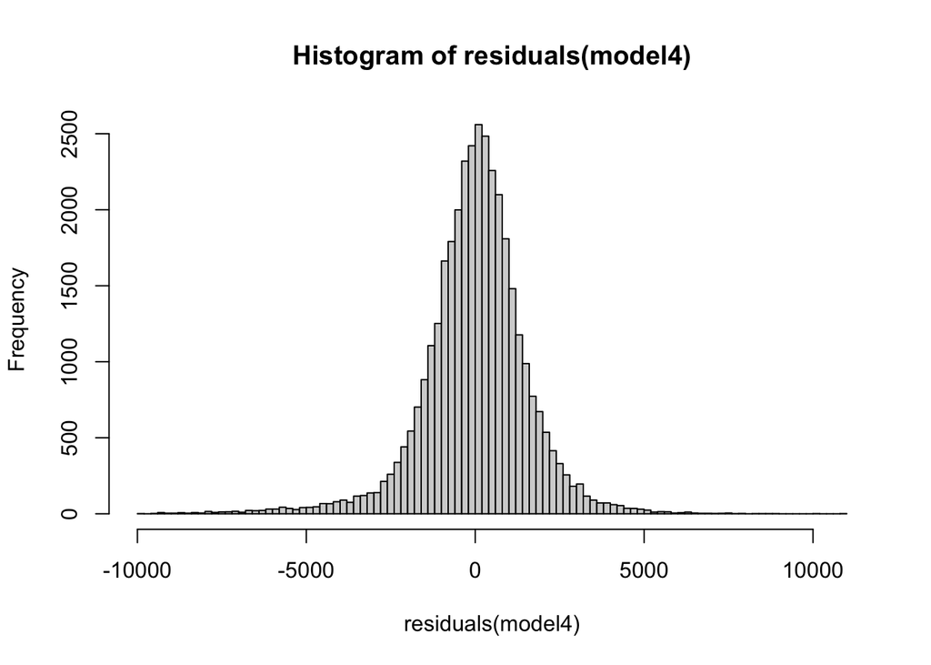

```r
data[ , residuals4 := residuals(model4)]
data[ , prediction4 := fitted(model4)]

hist(residuals(model4) , breaks =  100)
```

```r
data[residuals4 < -5000]$Consumption = data[residuals4 < -5000]$prediction4
data[residuals4 > 55000]$Consumption = data[residuals4 > 5500]$prediction4
```

### Model5:

As model5, we built the same model by model4 by using the exact same regressors. The difference is that we only used same regressors after fixing the outlier points and wanted to express the regressors’ new effects. Because our linear regression assumptions obligate us to have no autocorrelations on the residuals, we checked autocorrelation plot of the residuals of the model5 and realized high level on 160lag.

```r
model5 = lm(data$Consumption~data$Day + data$Average_T_1 +  data$Average_T_2 + data$Average_T_3 +data$Average_T_4 +data$Average_T_5 +data$Average_T_6 +data$Average_T_7 + data$index + data$Month + data$Hour  + data$prevweek  + data$prevday2)
summary(model5)
```

```
##
## Call:
## lm(formula = data$Consumption ~ data$Day + data$Average_T_1 +
##     data$Average_T_2 + data$Average_T_3 + data$Average_T_4 +
##     data$Average_T_5 + data$Average_T_6 + data$Average_T_7 +
##     data$index + data$Month + data$Hour + data$prevweek + data$prevday2)
##
## Residuals:
##     Min      1Q  Median      3Q     Max
## -5342.2  -781.7     4.9   772.5 11156.5
##
## Coefficients:
##                     Estimate Std. Error t value Pr(>|t|)
## (Intercept)        6.835e+03  1.544e+02  44.266  < 2e-16 ***
## data$DayCumartesi -7.715e+02  2.827e+01 -27.290  < 2e-16 ***
## data$DayÇarşamba   3.411e+02  2.792e+01  12.213  < 2e-16 ***
## data$DayPazar     -2.216e+03  3.260e+01 -67.962  < 2e-16 ***
## data$DayPazartesi  9.247e+01  2.828e+01   3.270  0.00108 **
## data$DayPerşembe   1.230e+02  2.762e+01   4.454 8.47e-06 ***
## data$DaySalı       1.329e+03  3.318e+01  40.066  < 2e-16 ***
## data$Average_T_1   8.016e+01  6.395e+00  12.534  < 2e-16 ***
## data$Average_T_2  -7.013e+01  5.535e+00 -12.669  < 2e-16 ***
## data$Average_T_3   4.497e+00  6.838e+00   0.658  0.51078
## data$Average_T_4  -1.256e+01  6.686e+00  -1.879  0.06024 .
## data$Average_T_5  -9.189e+01  7.073e+00 -12.992  < 2e-16 ***
## data$Average_T_6   9.323e+01  7.997e+00  11.658  < 2e-16 ***
## data$Average_T_7   1.189e+01  5.971e+00   1.991  0.04644 *
## data$index         1.449e-02  8.387e-04  17.281  < 2e-16 ***
## data$Month2       -3.423e+02  3.558e+01  -9.621  < 2e-16 ***
## data$Month3       -9.252e+02  3.986e+01 -23.211  < 2e-16 ***
## data$Month4       -1.212e+03  4.695e+01 -25.816  < 2e-16 ***
## data$Month5       -9.846e+02  6.045e+01 -16.287  < 2e-16 ***
## data$Month6       -2.236e+02  7.330e+01  -3.050  0.00229 **
## data$Month7        4.753e+02  7.978e+01   5.958 2.58e-09 ***
## data$Month8       -2.376e+02  7.998e+01  -2.971  0.00297 **
## data$Month9       -8.409e+02  7.263e+01 -11.578  < 2e-16 ***
## data$Month10      -1.294e+03  6.243e+01 -20.723  < 2e-16 ***
## data$Month11      -8.636e+01  4.676e+01  -1.847  0.06479 .
## data$Month12      -1.951e+02  3.691e+01  -5.287 1.25e-07 ***
## data$Hour1        -3.004e+02  5.140e+01  -5.844 5.15e-09 ***
```

[output cut: 15 more lines]

```
## data$Hour17        9.626e+02  5.482e+01  17.558  < 2e-16 ***
## data$Hour18        9.234e+02  5.468e+01  16.886  < 2e-16 ***
## data$Hour19        9.379e+02  5.471e+01  17.143  < 2e-16 ***
## data$Hour20        9.028e+02  5.447e+01  16.574  < 2e-16 ***
## data$Hour21        7.781e+02  5.361e+01  14.513  < 2e-16 ***
## data$Hour22        6.284e+02  5.274e+01  11.915  < 2e-16 ***
## data$Hour23        3.631e+02  5.162e+01   7.035 2.03e-12 ***
## data$prevweek      5.350e-01  3.621e-03 147.759  < 2e-16 ***
## data$prevday2      2.733e-01  3.712e-03  73.608  < 2e-16 ***
## ---
## Signif. codes:  0 '***' 0.001 '**' 0.01 '*' 0.05 '.' 0.1 ' ' 1
##
## Residual standard error: 1401 on 36141 degrees of freedom
## Multiple R-squared:  0.9184, Adjusted R-squared:  0.9183
## F-statistic:  8135 on 50 and 36141 DF,  p-value: < 2.2e-16
```

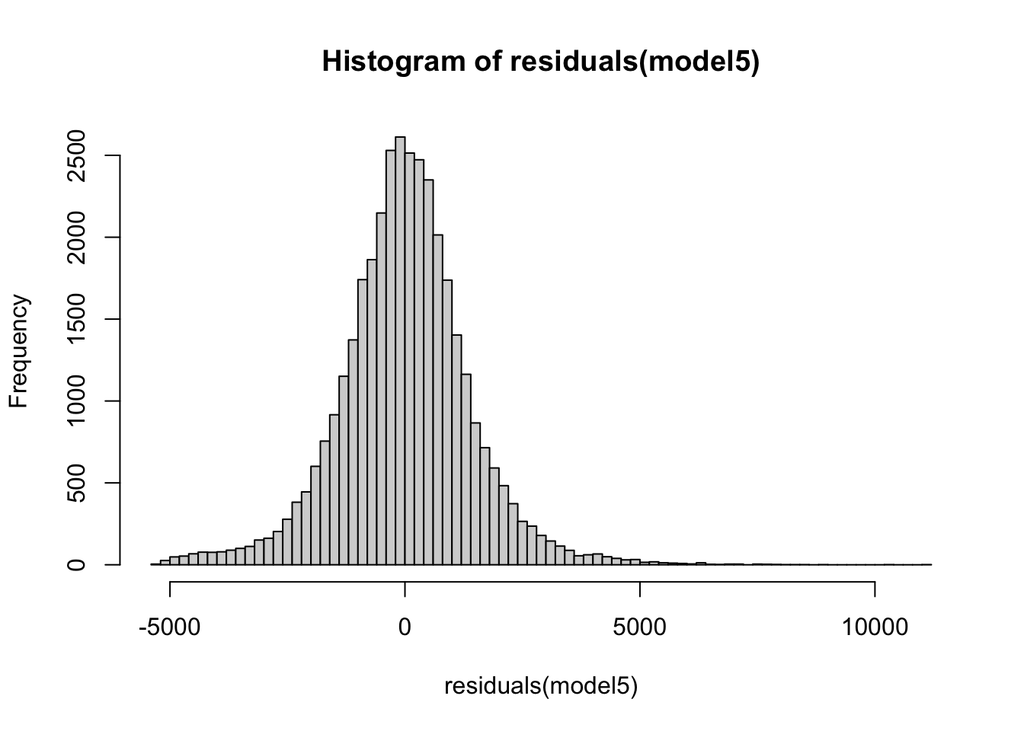

```r
data[ , residuals5 := residuals(model5)]
data[ , prediction5 := fitted(model5)]

hist(residuals(model5) , breaks = 100)
```

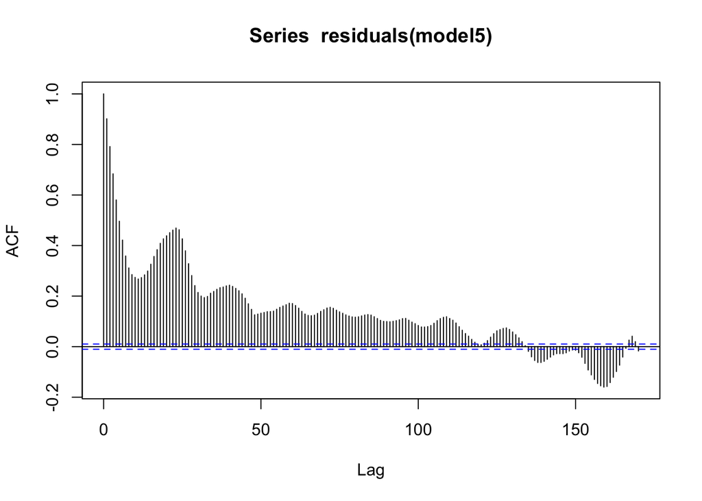

```r
acf(residuals(model5) , lag.max = 170)
```

### Model 6

For model5’ residuals have high autocorrelation on 160 lags, we built model6 where we use 160 lagged values of residuals obtained from model5 aiming to predict the residuals and indirectly consumptions.

```r
data[ , residuals5_l_160 := shift(data$residuals5 , n = 160L ,  fill = 0 )]
model6 <- lm(data$residuals5~  data$residuals5_l_160)
summary(model6)
```

```
##
## Call:
## lm(formula = data$residuals5 ~ data$residuals5_l_160)
##
## Residuals:
##     Min      1Q  Median      3Q     Max
## -5531.1  -754.6    12.4   777.6 10337.1
##
## Coefficients:
##                        Estimate Std. Error t value Pr(>|t|)
## (Intercept)            0.286367   7.266427   0.039    0.969
## data$residuals5_l_160 -0.158185   0.005203 -30.401   <2e-16 ***
## ---
## Signif. codes:  0 '***' 0.001 '**' 0.01 '*' 0.05 '.' 0.1 ' ' 1
##
## Residual standard error: 1382 on 36190 degrees of freedom
## Multiple R-squared:  0.0249, Adjusted R-squared:  0.02488
## F-statistic: 924.2 on 1 and 36190 DF,  p-value: < 2.2e-16
```

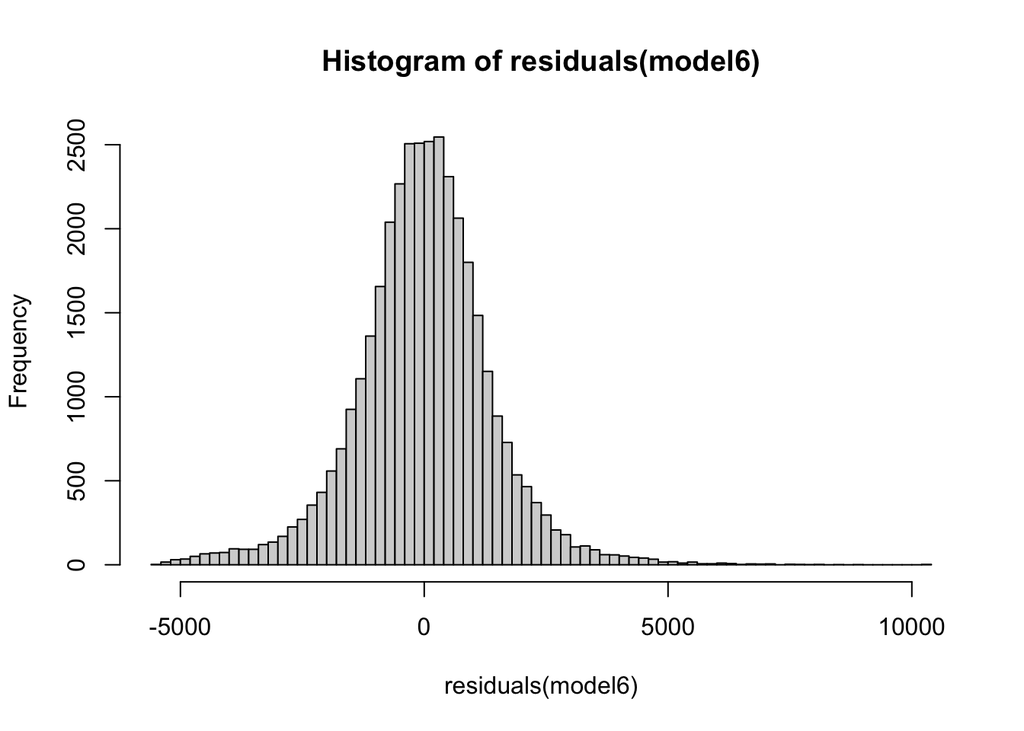

```r
data[ , residuals6 := residuals(model6)]
data[ , prediction6 := fitted(model6) + data$prediction5 ]

hist(residuals(model6) , breaks = 100)
```

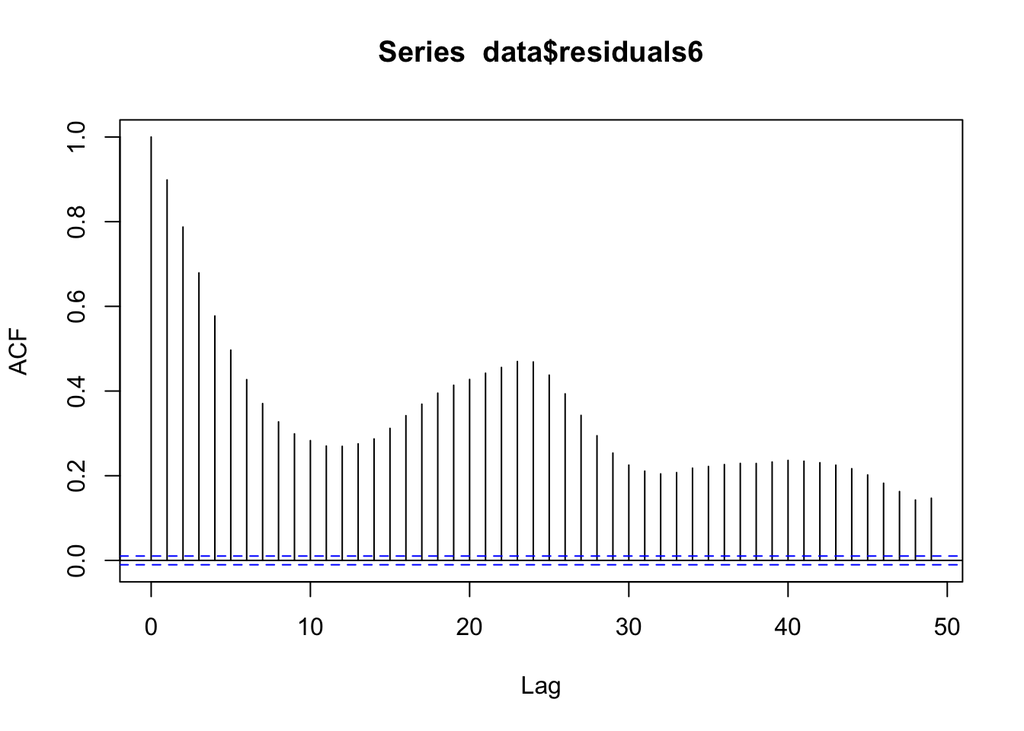

```r
acf(data$residuals6 , lag.max =  49)
```

### Model7

Realizing evident autocorrelation on the residuals of model6 on 48 lags, guided us to buil a model to predict model6’ residuals by using 48 lagged values. This is how we built model7.

```r
data[ ,residuals6_l_48 := shift(data$residuals6 , n = 48L , fill = 0)]
model7 = lm( data$residuals6 ~-1+ data$residuals6_l_48  )
summary(model7)
```

```
##
## Call:
## lm(formula = data$residuals6 ~ -1 + data$residuals6_l_48)
##
## Residuals:
##     Min      1Q  Median      3Q     Max
## -5765.4  -745.3    15.6   757.1  9644.4
##
## Coefficients:
##                      Estimate Std. Error t value Pr(>|t|)
## data$residuals6_l_48 0.143213   0.005213   27.47   <2e-16 ***
## ---
## Signif. codes:  0 '***' 0.001 '**' 0.01 '*' 0.05 '.' 0.1 ' ' 1
##
## Residual standard error: 1368 on 36191 degrees of freedom
## Multiple R-squared:  0.02043,    Adjusted R-squared:  0.0204
## F-statistic: 754.8 on 1 and 36191 DF,  p-value: < 2.2e-16
```

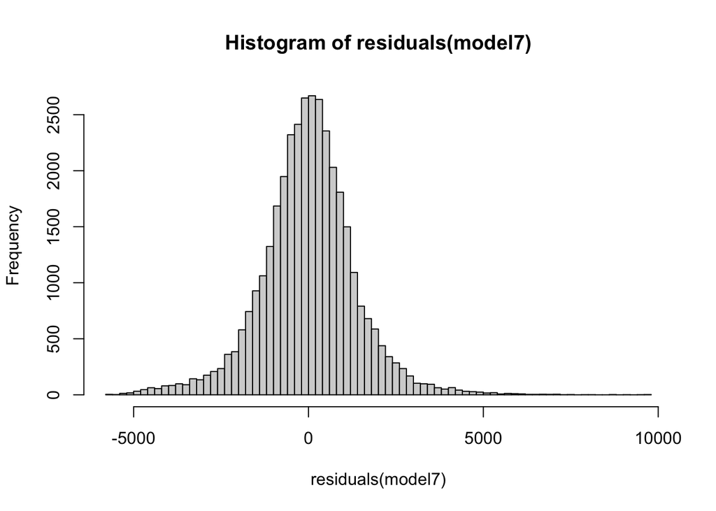

```r
data[ , residuals7 := residuals(model7)]
data[ ,prediction7 := fitted(model7) + prediction6]

hist(residuals(model7), breaks = 100)
```

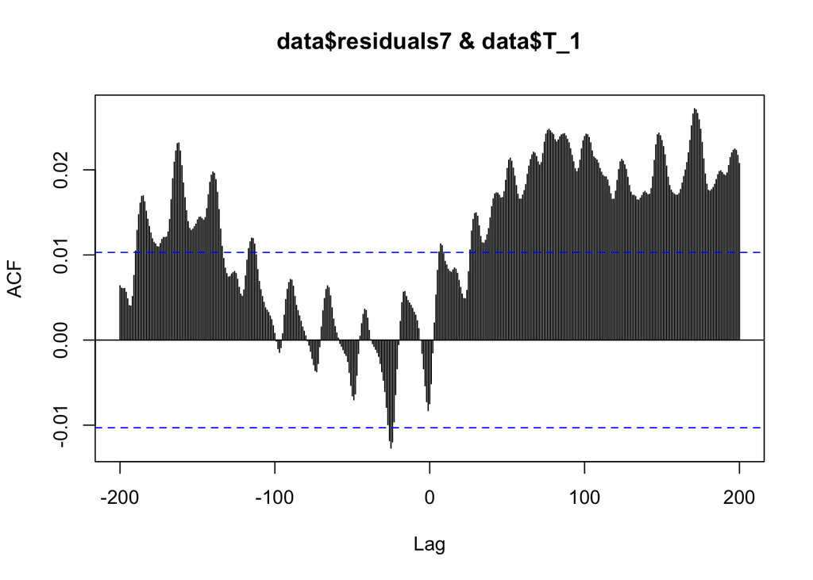

```r
#plot(data$residuals7, data$T_1)
#plot(data$residuals7, data$T_2)
#plot(data$residuals7, data$T_3)
#plot(data$residuals7, data$T_4)
#plot(data$residuals7, data$T_5)
#plot(data$residuals7, data$T_6)
#plot(data$residuals7, data$T_7)

ccf(data$residuals7 , data$T_1 , lag.max = 200)
```

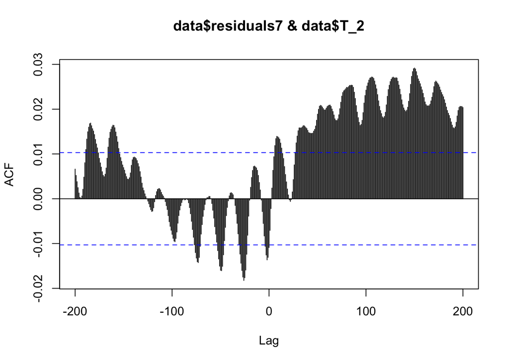

```r
ccf(data$residuals7 , data$T_2 , lag.max = 200)
```

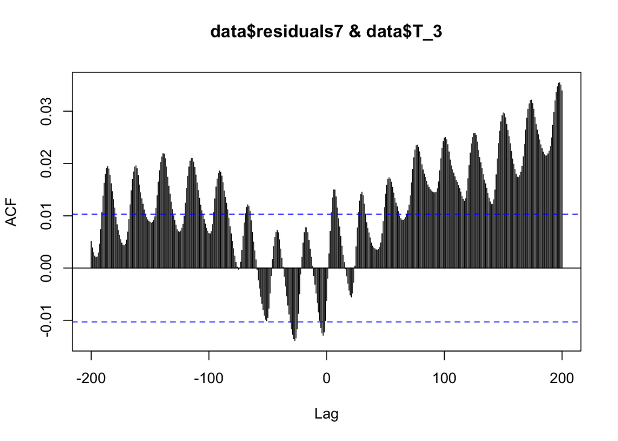

```r
ccf(data$residuals7 , data$T_3 , lag.max = 200)
```

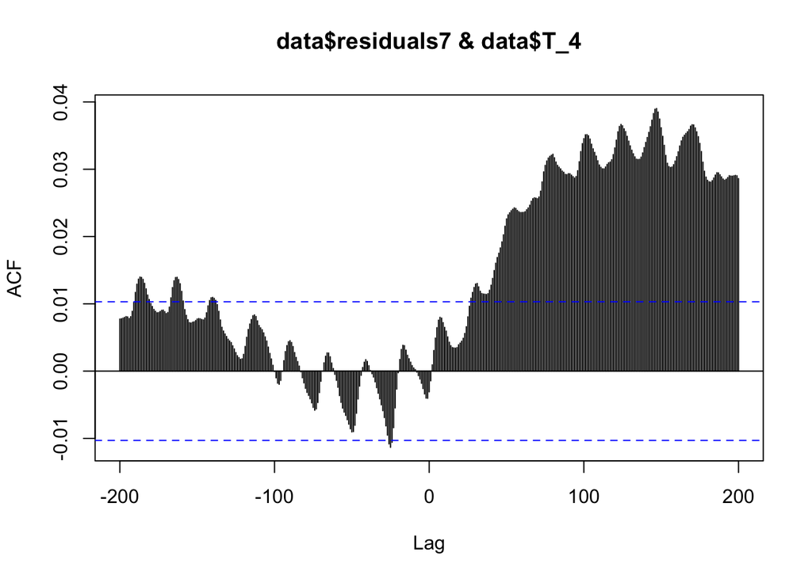

```r
ccf(data$residuals7 , data$T_4 , lag.max = 200)
```

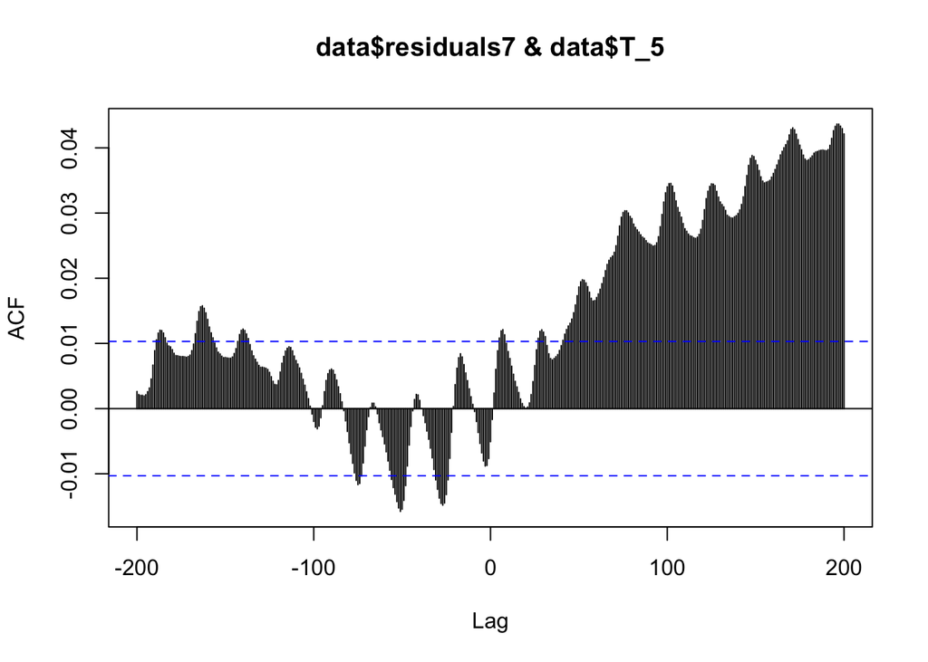

```r
ccf(data$residuals7 , data$T_5 , lag.max = 200)
```

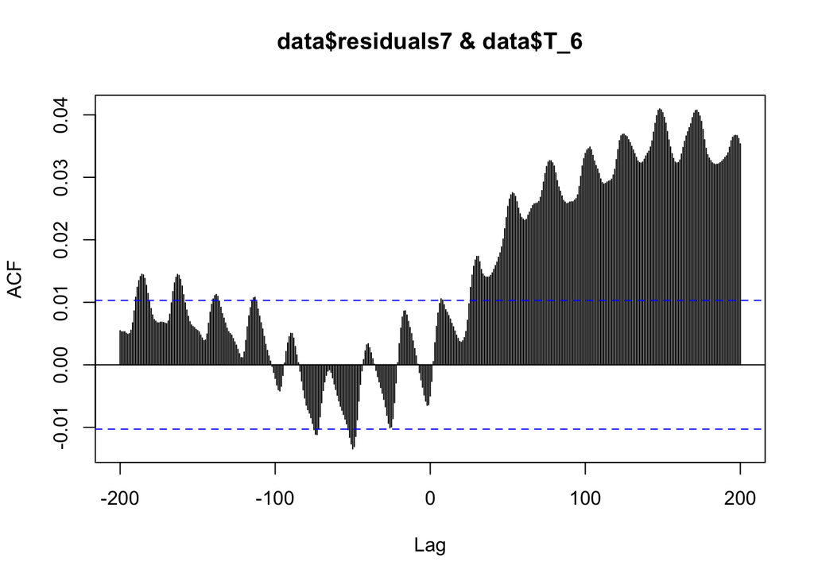

```r
ccf(data$residuals7 , data$T_6 , lag.max = 200)
```

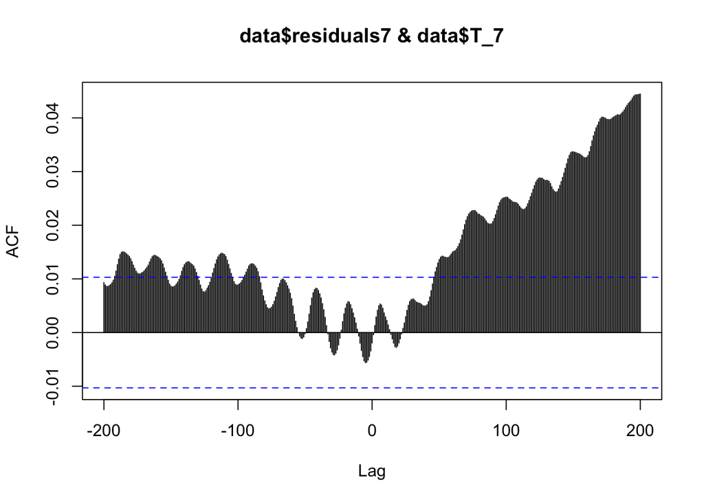

```r
ccf(data$residuals7 , data$T_7 , lag.max = 200)
```

### Model8

After realizing a distinctive crosscorrelations between residuals of model7 and all of the temperature values, we built model8 where we tried to predict residuals of model7 by using 168 lagged (one week) temperature values.

```r
data[ ,T_1_l_168 := shift(data$T_1 , n = 168L , fill = mean(data$T_1))]
data[ ,T_2_l_168 := shift(data$T_2 , n = 168L , fill = mean(data$T_2))]
data[ ,T_3_l_168 := shift(data$T_3 , n = 168L , fill = mean(data$T_3))]
data[ ,T_4_l_168 := shift(data$T_4 , n = 168L , fill = mean(data$T_4))]
data[ ,T_5_l_168 := shift(data$T_5 , n = 168L , fill = mean(data$T_5))]
data[ ,T_6_l_168 := shift(data$T_6 , n = 168L , fill = mean(data$T_6))]
data[ ,T_7_l_168 := shift(data$T_7 , n = 168L , fill = mean(data$T_7))]

model8 <- lm( data$residuals7 ~   data$T_1_l_168  +  data$T_2_l_168  +  data$T_3_l_168  +  data$T_4_l_168  +  data$T_5_l_168  +  data$T_6_l_168  +  data$T_7_l_168 )
summary(model8)
```

```
##
## Call:
## lm(formula = data$residuals7 ~ data$T_1_l_168 + data$T_2_l_168 +
##     data$T_3_l_168 + data$T_4_l_168 + data$T_5_l_168 + data$T_6_l_168 +
##     data$T_7_l_168)
##
## Residuals:
##     Min      1Q  Median      3Q     Max
## -5594.2  -737.4    12.4   746.9  9580.2
##
## Coefficients:
##                Estimate Std. Error t value Pr(>|t|)
## (Intercept)     101.431     43.515   2.331   0.0198 *
## data$T_1_l_168  -16.229      3.944  -4.115 3.88e-05 ***
## data$T_2_l_168   -7.966      3.292  -2.420   0.0155 *
## data$T_3_l_168  -38.744      3.808 -10.175  < 2e-16 ***
## data$T_4_l_168    1.761      4.615   0.382   0.7028
## data$T_5_l_168   33.397      4.353   7.673 1.73e-14 ***
## data$T_6_l_168   12.936      5.370   2.409   0.0160 *
## data$T_7_l_168   19.704      2.970   6.635 3.29e-11 ***
## ---
## Signif. codes:  0 '***' 0.001 '**' 0.01 '*' 0.05 '.' 0.1 ' ' 1
##
## Residual standard error: 1363 on 36184 degrees of freedom
## Multiple R-squared:  0.00765,    Adjusted R-squared:  0.007458
## F-statistic: 39.85 on 7 and 36184 DF,  p-value: < 2.2e-16
```

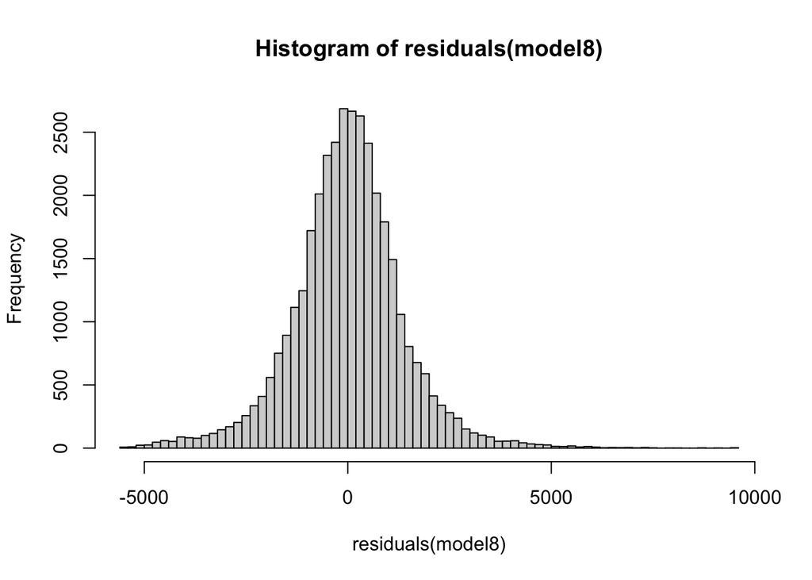

```r
data[ , residuals8 := residuals(model8)]
data[ ,prediction8 := fitted(model8) + prediction7]

hist(residuals(model8), breaks = 100)
```

### Model9

```r
data[ , residuals8_l_24 := shift( x = data$residuals8 , n = 24L , fill = 0) ]
model9 <- lm( data$residuals8 ~ -1 + data$residuals8_l_24 )
summary(model9)
```

```
##
## Call:
## lm(formula = data$residuals8 ~ -1 + data$residuals8_l_24)
##
## Residuals:
##     Min      1Q  Median      3Q     Max
## -7617.1  -640.3    17.2   670.7  9893.6
##
## Coefficients:
##                      Estimate Std. Error t value Pr(>|t|)
## data$residuals8_l_24 0.389263   0.004848    80.3   <2e-16 ***
## ---
## Signif. codes:  0 '***' 0.001 '**' 0.01 '*' 0.05 '.' 0.1 ' ' 1
##
## Residual standard error: 1256 on 36191 degrees of freedom
## Multiple R-squared:  0.1512, Adjusted R-squared:  0.1512
## F-statistic:  6448 on 1 and 36191 DF,  p-value: < 2.2e-16
```

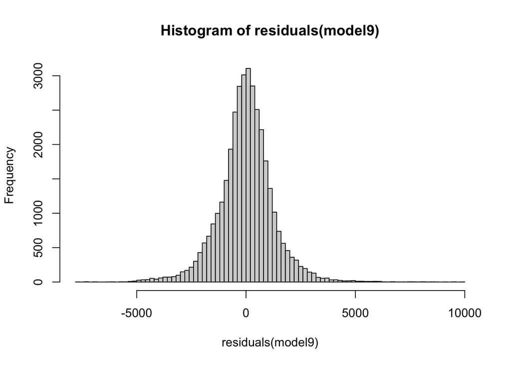

```r
data[ , residuals9 := residuals(model9)]
data[ ,prediction9 := fitted(model9) + prediction8]

hist(residuals(model9) , breaks = 100)
```

# Problems We Have Faced and our Approaches

During this project, we faced 6 major problems. Presence of outlier observations, hourly fluctiations leading an overfit in regression models, presence of high number of observations reducing the affect of the most recent observations, varying lockdown strategies going on for almost a year, residuals obtained from our models are not being independent from the day and incomplete past data, that is we did not have all observations of day = “t” when we were trying to predict day = “t+1”.

## Outliers

The method we used in order to handle the outlier points was replacing them with their predictions. Since we knew the reason behind being an outlier was being a special day for the scope of this project and we were aware of we will not need to predict this points in the time of this project, discarding this observations was one of the most efficient and convinient method we kome up with.

## Hourly Fluctaitions of Temperature Values

In order to avoid the hourly fluctuations of temperature to cause an overfit in our model, we introduced a set of daily average temperatures for every day and every interested city.

## Varying Lockdown Strategies

Lockdown strategies differing leads an obstacle. The method we followed was benefiting from previous residuals. Since lockdown strategies have high autocorrelations, we utilized previous residuals in our model as regressors.

## Residuals Being Dependent on Weekdays

After using lagged residuals as regressors, we noticed that althought residuals have high autocorrelations, they were dependent on the weekdays, as mostly residuals of sundays highly differ. And this status created a difficulty while predicting sundays and using sundays’ residuals as regressors. In order to handle this problem we came up with the idea of seperating sundays as a whole new dataset and building models by using same methods and regressors on it. But since we discovered this problem in a point where we do not have any sundas to predict, we did not coded this model.

## Incomplete Past Data

We did not have previous days’ consumption observations in imported data set although some of the previous days’ observations were published online(mostly between hours 0 and 9). And we realized that our residuals had hig autocorrelations on 24 lag. In order to improve our model, we manually entered most recent observations of the day we were in (hours 0-9).

#8 Testing the Model

```r
resultsp = vector('list' , 744)

# 1 aralık 34344
# 1 ocak 35088

for(i in 0:30){

  datat = data[ index <= 34344 + 24*i]

  datat[ index >= 34344 - 37 + 24*i  ]$Consumption = -1


  ############################################

  model1 = lm(datat$Consumption~ datat$Average_T_1 +  datat$Average_T_2 + datat$Average_T_3 +datat$Average_T_4 + datat$Average_T_5 + datat$Average_T_6 +datat$Average_T_7 + datat$Hour  )
datat[, residuals1 := residuals(model1)]
datat[, prediction1 := fitted(model1)]

model2 = lm(datat$Consumption~ datat$T_1 + datat$T_2 + datat$T_3 + datat$T_4 + datat$T_5 + datat$T_6 + datat$T_7  + datat$index + datat$Month + datat$Day + datat$Hour )
datat[, residuals2 := residuals(model2)]
datat[ , prediction2 := fitted(model2)]

datat[ datat$residuals2 < -7000]$Consumption = datat[ datat$residuals2 < -7000]$prediction2
datat[ datat$residuals2 > 8000]$Consumption = datat[ datat$residuals2 > 8000]$prediction2


datat[,prevday2:=shift(x=datat$Consumption,n=48L,fill=mean(datat$Consumption))]
datat[,prevweek:=shift(x=datat$Consumption,n=168L,fill=mean(datat$Consumption))]


model3 = lm(datat$Consumption~datat$Day + datat$T_1 + datat$T_2 + datat$T_3 + datat$T_4 + datat$T_5 + datat$T_6 + datat$T_7   + datat$index + datat$Month + datat$Hour  + datat$prevday2  )
datat[, residuals3 := residuals(model3)]
datat[, prediction3 := fitted(model3)]


model4 = lm(datat$Consumption~datat$Day + datat$Average_T_1 +  datat$Average_T_2 + datat$Average_T_3 +datat$Average_T_4 +datat$Average_T_5 +datat$Average_T_6 +datat$Average_T_7 + datat$index + datat$Month + datat$Hour + datat$prevweek +datat$prevday2 )
datat[ , residuals4 := residuals(model4)]
datat[ , prediction4 := fitted(model4)]

datat[residuals4 < -5000]$Consumption = datat[residuals4 < -5000]$prediction4
datat[residuals4 > 55000]$Consumption = datat[residuals4 > 5500]$prediction4

model5 = lm(datat$Consumption~datat$Day + datat$Average_T_1 +  datat$Average_T_2 + datat$Average_T_3 +datat$Average_T_4 +datat$Average_T_5 +datat$Average_T_6 +datat$Average_T_7 + datat$index + datat$Month + datat$Hour  + datat$prevweek  + datat$prevday2)
datat[ , residuals5 := residuals(model5)]
datat[ , prediction5 := fitted(model5)]


datat[ , residuals5_l_160 := shift(datat$residuals5 , n = 160L ,  fill = 0 )]

model6 <- lm(datat$residuals5~  datat$residuals5_l_160)
datat[ , residuals6 := residuals(model6)]
datat[ , prediction6 := fitted(model6) + datat$prediction5 ]

datat[ ,residuals6_l_48 := shift(datat$residuals6 , n = 48L , fill = 0)]

model7 = lm( datat$residuals6 ~-1+ datat$residuals6_l_48  )
datat[ , residuals7 := residuals(model7)]
datat[ ,prediction7 := fitted(model7) + prediction6]

datat[ ,T_1_l_168 := shift(datat$T_1 , n = 168L , fill = mean(datat$T_1))]
datat[ ,T_2_l_168 := shift(datat$T_2 , n = 168L , fill = mean(datat$T_2))]
datat[ ,T_3_l_168 := shift(datat$T_3 , n = 168L , fill = mean(datat$T_3))]
datat[ ,T_4_l_168 := shift(datat$T_4 , n = 168L , fill = mean(datat$T_4))]
datat[ ,T_5_l_168 := shift(datat$T_5 , n = 168L , fill = mean(datat$T_5))]
datat[ ,T_6_l_168 := shift(datat$T_6 , n = 168L , fill = mean(datat$T_6))]
datat[ ,T_7_l_168 := shift(datat$T_7 , n = 168L , fill = mean(datat$T_7))]

model8 <- lm( datat$residuals7 ~   datat$T_1_l_168  +  datat$T_2_l_168  +  datat$T_3_l_168  +  datat$T_4_l_168  +  datat$T_5_l_168  +  datat$T_6_l_168  +  datat$T_7_l_168 )
datat[ , residuals8 := residuals(model8)]
datat[ ,prediction8 := fitted(model8) + prediction7]

datat[ , residuals8_l_24 := shift( x = datat$residuals8 , n = 24L , fill = 0) ]

model9 <- lm( datat$residuals8 ~ -1 + datat$residuals8_l_24 )
datat[ , residuals9 := residuals(model9)]
datat[ ,prediction9 := fitted(model9) + prediction8]

  ############################################


resultsp[ 1 + 24*i] = datat[index == 34321 + 24*i]$prediction9
resultsp[ 2 + 24*i] = datat[index == 34322+ 24*i]$prediction9
resultsp[ 3 + 24*i] = datat[index == 34323 + 24*i]$prediction9
resultsp[ 4 + 24*i] = datat[index == 34324 + 24*i]$prediction9
resultsp[ 5 + 24*i] = datat[index == 34325 + 24*i]$prediction9
resultsp[ 6 + 24*i] = datat[index == 34326 + 24*i]$prediction9
resultsp[ 7 + 24*i] = datat[index == 34327 + 24*i]$prediction9
resultsp[ 8 + 24*i] = datat[index == 34328 + 24*i]$prediction9
resultsp[ 9 + 24*i] = datat[index == 34329 + 24*i]$prediction9
resultsp[ 10 + 24*i] = datat[index == 34330+ 24*i]$prediction8
resultsp[ 11 + 24*i] = datat[index == 34331+ 24*i]$prediction8
resultsp[ 12 + 24*i] = datat[index == 34332+ 24*i]$prediction8
resultsp[ 13 + 24*i] = datat[index == 34333+ 24*i]$prediction8
resultsp[ 14 + 24*i] = datat[index == 34334+ 24*i]$prediction8
resultsp[ 15 + 24*i] = datat[index == 34335+ 24*i]$prediction8
resultsp[ 16 + 24*i] = datat[index == 34336+ 24*i]$prediction8
resultsp[ 17 + 24*i] = datat[index == 34337+ 24*i]$prediction8
resultsp[ 18 + 24*i] = datat[index == 34338+ 24*i]$prediction8
resultsp[ 19 + 24*i] = datat[index == 34339+ 24*i]$prediction8
resultsp[ 20 + 24*i] = datat[index == 34340+ 24*i]$prediction8
resultsp[ 21 + 24*i] = datat[index == 34341+ 24*i]$prediction8
resultsp[ 22 + 24*i] = datat[index == 34342+ 24*i]$prediction8
resultsp[ 23 + 24*i] = datat[index == 34343+ 24*i]$prediction8
resultsp[ 24 + 24*i] = datat[index == 34344+ 24*i]$prediction8


}
```

```r
Predictions = resultsp
Predictions = rbind(Predictions)
Predictions = t(Predictions)
Predictions = as.data.table(Predictions[,1])
Predictions = t(Predictions)
Predictions = as.data.table(Predictions)
colnames(Predictions) = c("Predictions")


Observations = data[ index >= 34321 & index <= 35064]$Consumption
Observations = data.table(Observations)
colnames(Observations) = c("Actual")

Naive = data[ index >= 34321 - 24 & index <= 35064- 24 ]$Consumption
Naive = data.table(Naive)
colnames(Naive) = c("Naive Forecast")


testing = cbind(Predictions,Observations,Naive)


output(testing$Actual , testing$Naive)
```

```
##     n     mean       sd         bias       mape      mad      wmape
## 1 744 35337.38 4386.023 -0.001576037 0.05218185 1832.214 0.05184916
```

```r
output(testing$Actual , testing$Predictions)
```

```
##     n     mean       sd        bias       mape      mad      wmape
## 1 744 35337.38 4386.023 -0.00110128 0.02588973 911.6944 0.02579972
```

# Conclusion

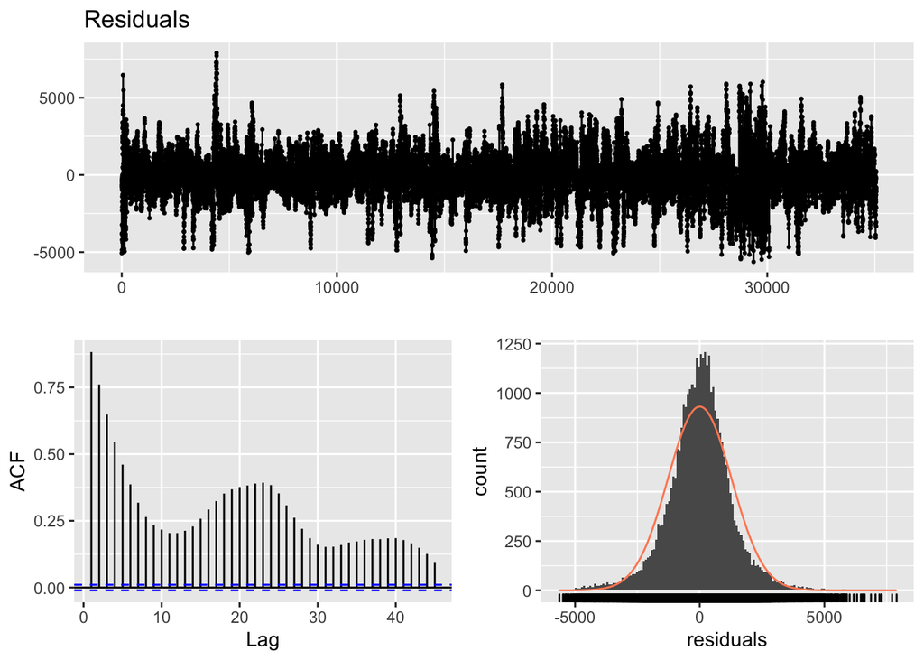

```
##
##  Breusch-Godfrey test for serial correlation of order up to 11
##
## data:  Residuals
## LM test = 27438, df = 11, p-value < 2.2e-16
```

```r
checkresiduals(model8)
```

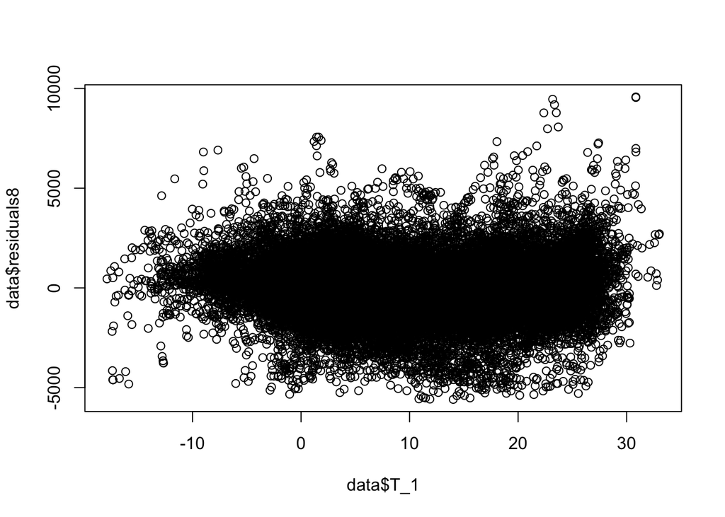

```r
plot(data$T_1 , data$residuals8)
```

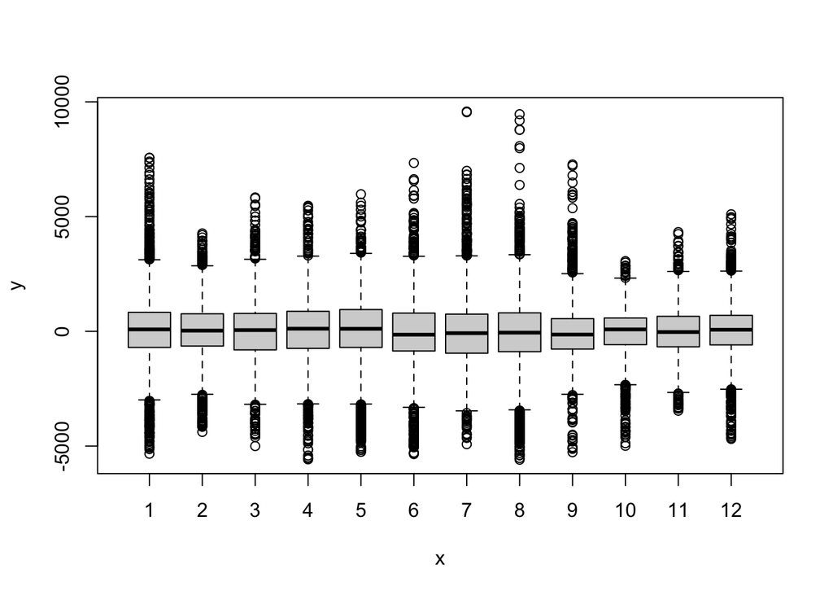

```r
plot(data$Month , data$residuals8)
```

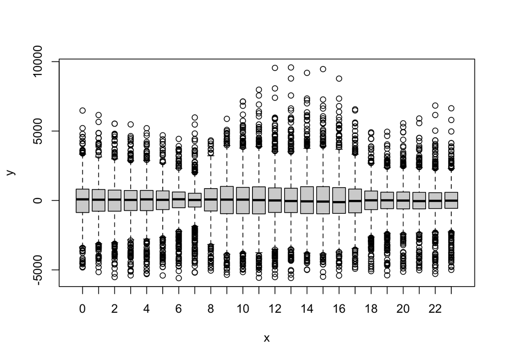

```r
plot(data$Hour , data$residuals8)
```

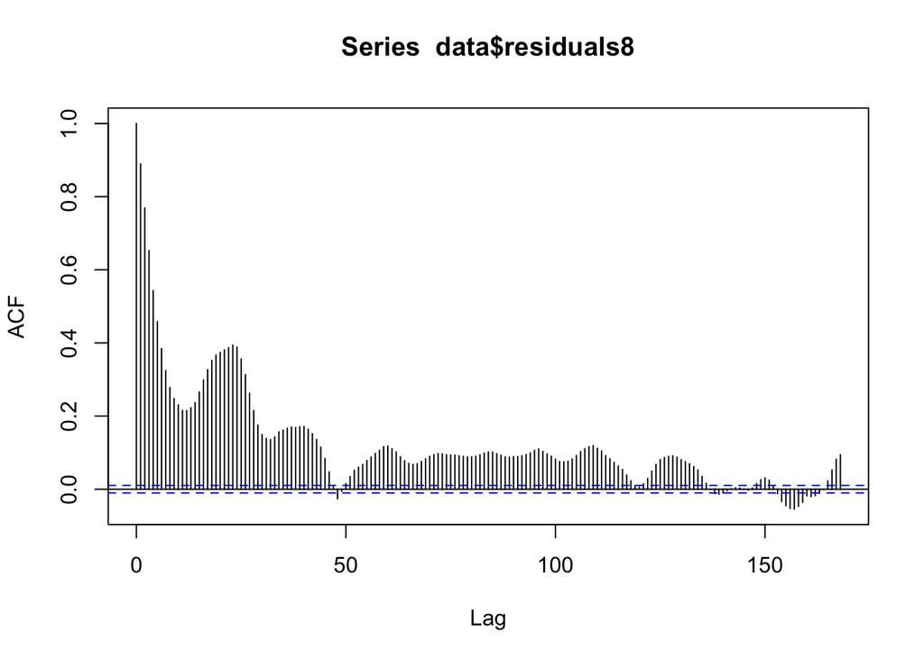

```r
acf(data$residuals8 , lag.max = 24*7)
```